# Technology and Social Change

Lecture 8: Industrial Revolution

Bogdan G. Popescu

bgpopescu@tec.mx

Tecnológico de Monterrey

# Motivation & Framing

## Why Study the Industrial Revolution?

- Productivity gains were unprecedented in human history
- Created institutions we still live with today
- Offers a template for thinking about AI and automation

> “[The Industrial Revolution] was probably the most important event in world history, at any rate since the invention of agriculture and cities.” — E. J. Hobsbawm, *The Age of Revolution* (1962)

[figure not shown]

*Coalbrookdale by Night* (1801), Philip James de Loutherbourg. The iron works at Coalbrookdale, Shropshire — an icon of early industrialization. Source: Wikimedia Commons (public domain).

## A Before-and-After Snapshot

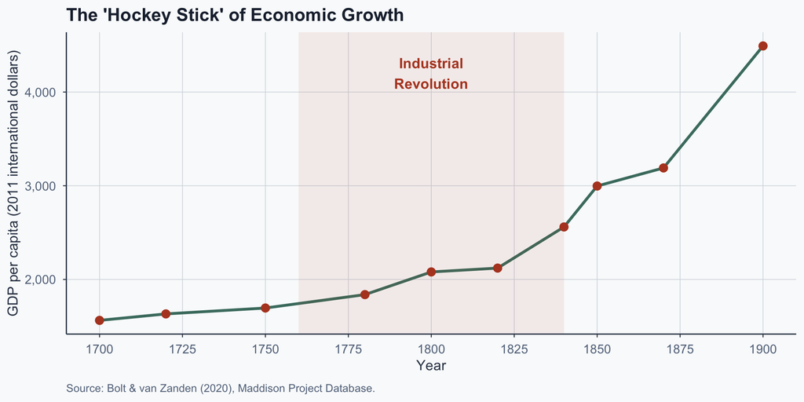

Figure 1: UK GDP per capita, 1700–1900

## The Core Puzzle

### Technology outpaces institutions

- New technologies create gains — but also disruption
- Institutions (laws, norms, organizations) adapt slowly
- The gap between technology and institutions produces conflict
- Understanding this lag is the key to the entire lecture

## The Technology–Institution Gap

```
%%{init:{
  "flowchart":{"useMaxWidth":true,"nodeSpacing":70,"rankSpacing":80},
  "themeVariables":{"fontSize":"22px"},
  "width":1150,
  "height":650
}}%%
flowchart LR
  A["New Technology<br/>(e.g., Steam Engine)"] --> B["Productivity<br/>Gains"]
  B --> C["Social<br/>Disruption"]
  C --> D["Institutional<br/>Lag"]
  D --> E["Political<br/>Pressure"]
  E --> F["Institutional<br/>Adaptation"]
  F --> G["New<br/>Equilibrium"]
  G -.->|"Next shock"| A

  style A fill:#4a7c6f,color:#fff,stroke:#334155
  style C fill:#b44527,color:#fff,stroke:#334155
  style F fill:#4a7c6f,color:#fff,stroke:#334155
  style G fill:#b7943a,color:#fff,stroke:#334155
```

Author’s illustration of the technology–institution gap cycle.

# Conceptual Foundations

## General-Purpose Technologies (GPTs)

### A technology that transforms an entire economy

- Pervasive: used across many sectors
- Improvable: performance increases over time
- Spawns innovation: enables new products and processes
- Examples: steam, electricity, the internet

Key insight: GPTs do not just improve one task — they restructure the economy (Bresnahan & Trajtenberg, 1995).

## Comparing GPTs Across Eras

GPTs share common diffusion patterns.

| Feature | Steam (1770s) | Electricity (1890s) | Digital/AI (1990s) |
| --- | --- | --- | --- |
| Pervasiveness | High | Very High | Very High |
| Improvement arc (years to mature) | ~80 years | ~50 years | Ongoing |
| Skill complement (worker expertise needed) | Low → High | Medium → High | High |
| Institutional lag (time for laws, norms to catch up) | ~60 years | ~40 years | ? |

Source: Adapted from Lipsey, Carlaw, & Bekar (2005).

## Technology vs. Organization of Production

- Technology = the machines and techniques
- Organization = how production is arranged (firms, contracts, labor)
- The same technology can yield different outcomes under different organizations
- The factory system was an organizational innovation, not just a technological one

As Mokyr (2002) argues, the factory was fundamentally a new way of organizing people — not just machines.

## Complementarity Framework

### Technology, Skills, and Institutions

```
%%{init:{
  "flowchart":{"useMaxWidth":true,"nodeSpacing":60,"rankSpacing":80},
  "themeVariables":{"fontSize":"22px"},
  "width":1150,
  "height":650
}}%%
flowchart LR
  T["Technology"] <--> S["Skills"]
  S <--> I["Institutions"]
  I <--> T
  T --> O["Economic<br/>Output"]
  S --> O
  I --> O

  style T fill:#4a7c6f,color:#fff,stroke:#334155
  style S fill:#b44527,color:#fff,stroke:#334155
  style I fill:#b7943a,color:#fff,stroke:#334155
  style O fill:#1e293b,color:#fff,stroke:#334155
```

**Key idea:** Changing one element without the others creates misalignment and friction.

Author’s illustration based on Milgrom & Roberts (1990).

## Discussion Exercise 1

### Identifying General-Purpose Technologies

**Prompt:** Argue that the smartphone is **not** a General-Purpose Technology. Which of the three criteria does it fail — or does the GPT framework itself have limits? Be prepared to defend your position.

**Format:** Pairs, then brief class share

**Time:** 5 minutes

# Technological Core

## Case Evidence: Why Britain?

[video not shown]

Source: https://www.youtube.com/watch?v=fuWeGHknCjk

1. Why does Allen argue that high wages — not genius — drove mechanization in Britain?  
2. How does the British Empire connect to the invention of the spinning jenny?  
3. Why didn’t the spinning jenny get invented in other countries at the same time?

## Allen’s Argument: Why Britain?

### Empire → high wages → incentive to mechanize

- Rate of return on a spinning jenny: **2–3%** elsewhere (not worth it) → **30–40%** in Britain (very profitable)
- The knowledge to build a jenny existed everywhere — only Britain had the wages to make it pay

> “The Industrial Revolution was the knock-on effect of British imperialism.” — Robert C. Allen

Source: Allen (2009), *The British Industrial Revolution in Global Perspective*, Cambridge UP.

## Steam Power and Mechanization

- Newcomen engine (1712): pumped water from mines
- Watt’s separate condenser (1769): doubled efficiency
- Rotary motion adaptation (1781): powered factories
- Steam became the universal energy source by 1830s

Steam was the GPT of the Industrial Revolution — it connected mining, textiles, transport, and manufacturing.

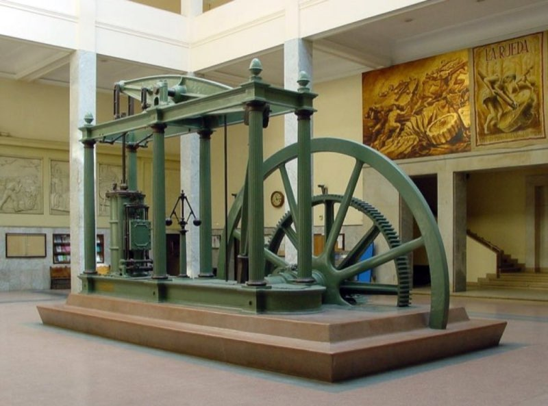

A Watt steam engine: the separate condenser dramatically improved efficiency over earlier designs. Source: Wikimedia Commons (public domain).

## From Cottage Industry to Factory

### Two systems of production

- **Putting-out system:** merchants supplied raw materials to home workers
- **Factory system:** workers gathered under one roof with powered machinery
- Division of labor broke tasks into repetitive steps; management hierarchies emerged
- Factories enabled supervision, quality control, and continuous operation

. . .

The shift from putting-out to factory concentrated workers, capital, and power under one roof — creating the conditions for both rapid output growth and new social tensions.

[figure not shown]

Power loom weaving in a textile factory, c. 1835. Source: T. Allom illustration; Wikimedia Commons (public domain).

## The Coal Revolution

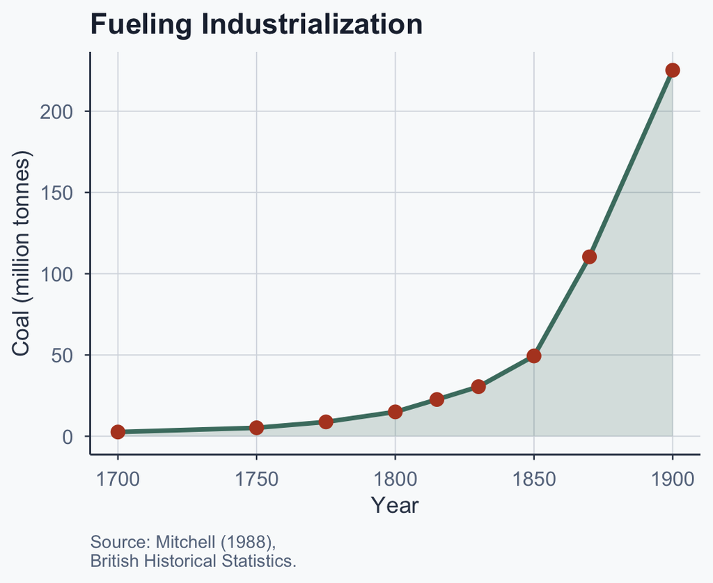

Figure 2: UK coal production, 1700–1900

[figure not shown]

*Pitmen Hewing the Coal* (1871), from *The Graphic*. Miners at the coal face with pit pony and cart. Source: Wikimedia Commons (public domain).

## The Structural Shift in Labor

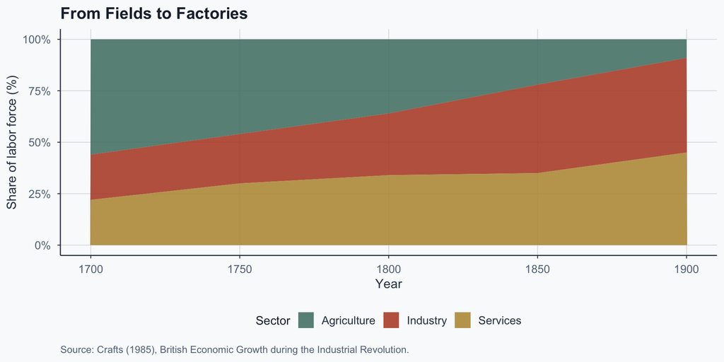

Figure 3: UK labor force by sector, 1700–1900

# Labor & Social Transformation

## The Shift to Wage Labor

- Pre-industrial workers often controlled their own time
- Factories created a new relationship: employer–employee
- Workers sold their labor for a wage, not a product
- This was a profound change in economic and social identity

> “He becomes an appendage of the machine.” — Karl Marx & Friedrich Engels, *The Communist Manifesto* (1848)

## Deskilling and Reskilling

### A dual process

- **Deskilling:** artisan knowledge replaced by machine routines
- Handloom weavers, for example, saw wages collapse after 1800
- **Reskilling:** new occupations required new expertise
- Engineers, overseers, and machine operators were in demand

. . .

The net effect: a polarized labor market — high skill vs. low skill.

## Case Evidence: Factory Time

[video not shown]

Source: https://www.youtube.com/watch?v=hY4ptEzxNwM

1. How did “slave clocks” give mill owners control over their workforce?  
2. Why is the shift from seasonal rhythms to clock time a social transformation, not just a technical one?

## Time Discipline and New Class Structures

- Factory work imposed clock time on daily life
- Work rhythms shifted from task-oriented to time-oriented
- A new industrial working class emerged in cities
- A new capitalist class controlled the means of production

> “The first generation of factory workers were taught by their masters the importance of time.” — E. P. Thompson (1967)

## So What?

> The factory system didn’t just change *what* was produced — it changed *who controlled production*. Wage labor, clock discipline, and deskilling created a new class of workers with no ownership stake and no bargaining power.

**Next →** How were the gains from productivity growth actually distributed?

# Inequality & Social Conflict

## The Distributional Paradox

- National output grew rapidly after 1780
- But real wages for workers stagnated for decades
- The gains went disproportionately to capital owners
- This pattern is called “Engels’ Pause” (Allen, 2009)

**Key question:** Why did it take so long for workers to share in the gains?

## Engels’ Pause: Wages vs. Output

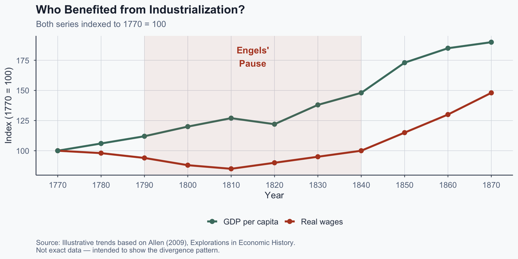

Figure 4: Real wages lagged GDP per capita for decades

## Was Engels’ Pause Real?

Not all historians agree. The debate matters.

- **Allen (2009):** Real wages stagnated 1790–1840 while GDP surged — the pause is real and large
- **Clark (2005):** Wages rose earlier than Allen claims; the gap is smaller and shorter
- **Feinstein (1998):** Living standards improved slowly but steadily — no dramatic pause
- **Measurement problems:** Which price index? Which workers? Regional variation is enormous (London vs. Lancashire)

**The point is not who is right — it’s that “growth” and “shared prosperity” are not the same thing, and measuring the difference is harder than it looks.**

## Urbanization and Social Dislocation

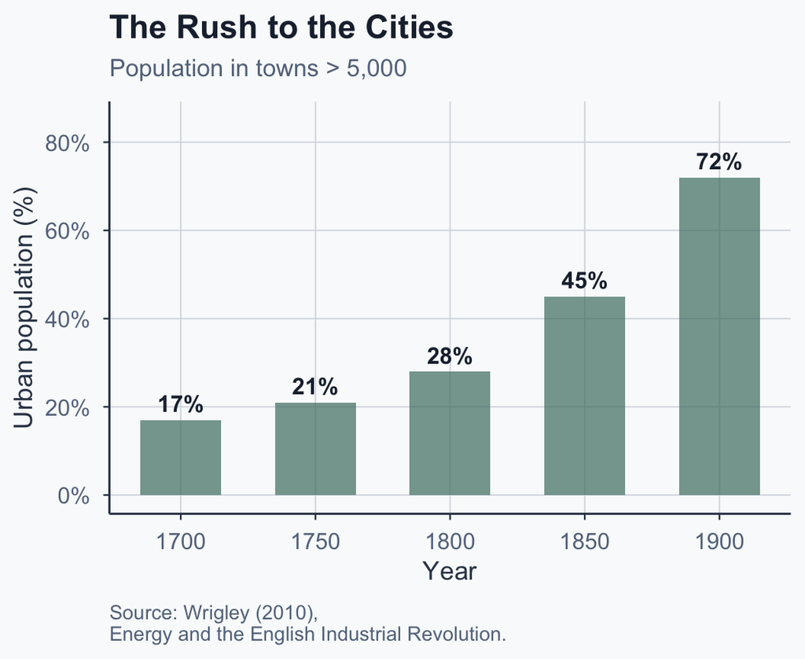

Figure 5: English urbanization rate, 1700–1900

[figure not shown]

*Over London — by Rail* (c. 1870), Gustave Doré. Dense Victorian housing viewed from a railway viaduct — the human face of rapid urbanization. Source: Wikimedia Commons (public domain).

## So What?

> Surplus labor kept wages down; the absence of unions meant no collective bargaining; no factory regulation meant no floor on conditions. The mechanisms that sustained Engels’ Pause were economic *and* political — and breaking them required organized pressure, not just time.

**Next →** How did institutions eventually respond?

# Institutional & Political Responses

## Case Evidence: The Push for Regulation

[video not shown]

Source: https://www.youtube.com/watch?v=hY4ptEzxNwM

1. Why did mill owner Greg argue *against* the Ten Hours Act — and was he wrong?  
2. Why were Factory Acts poorly enforced, and what does this tell us about institutional lag?

## Labor Regulation and Education

- Factory Acts (1833–1847) limited child labor and working hours — resisted by owners at every step
- Compulsory education (1870–1880) eventually made workers more productive

Institutions adapted — but it took decades, and only under political pressure.

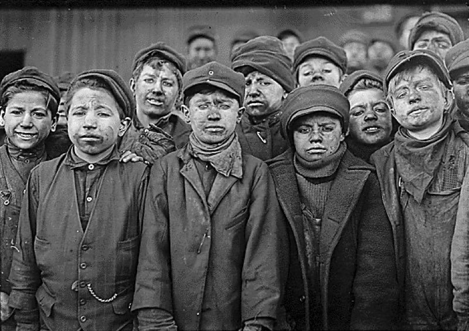

## Why Did Elites Concede?

Elites didn’t reform out of goodwill — the costs of *not* reforming became too high.

- **Threat:** Luddism, Chartism, food riots — revolution was not hypothetical (France 1789, 1830, 1848)
- **Organization:** Unions gave workers collective power that individual bargaining never could
- **Elections:** Reform Acts (1832, 1867) forced politicians to answer to working-class voters

Institutional change is not evolution — it is political conflict with winners and losers.

## Key Institutional Reforms

Institutional responses lagged the onset of industrialization by 40–60 years.

| Year | Reform | Purpose |
| --- | --- | --- |
| 1833 | Factory Act | Limited child labor in textiles |
| 1834 | Poor Law Amendment | Restructured public relief |
| 1842 | Mines Act | Banned women and children underground |
| 1847 | Ten Hours Act | Capped the factory working day |
| 1870 | Education Act | Introduced compulsory schooling |
| 1884 | Third Reform Act | Extended male suffrage |

Source: Compiled from standard legislative records.

## Path Dependence in Institutional Change

```
%%{init:{
  "flowchart":{"useMaxWidth":true,"nodeSpacing":50,"rankSpacing":60},
  "themeVariables":{"fontSize":"20px"},
  "width":1150,
  "height":650
}}%%
flowchart LR
  A["Pre-industrial<br/>Institutions"] --> B{"Critical Juncture:<br/>Factory System"}
  B -->|"Reform"| C["Factory Acts &<br/>Education Acts"]
  B -->|"Laissez-faire"| D["Minimal<br/>regulation"]
  C --> E["Regulated<br/>labor market"]
  D --> F["Persistent<br/>inequality"]
  E --> G["Welfare state<br/>(20th century)"]
  F --> H["Social<br/>instability"]

  style A fill:#64748b,color:#fff,stroke:#334155
  style B fill:#b44527,color:#fff,stroke:#334155
  style C fill:#4a7c6f,color:#fff,stroke:#334155
  style D fill:#b7943a,color:#fff,stroke:#334155
  style G fill:#4a7c6f,color:#fff,stroke:#334155
  style H fill:#b44527,color:#fff,stroke:#334155
```

Author’s illustration based on Acemoglu & Robinson (2012).

# Comparative Link to Today

## IR vs. AI/Automation: Parallels

- Both are general-purpose technologies transforming many sectors
- Both create a gap between technology and institutions
- Both produce winners and losers based on skill levels
- Both provoke anxiety about the future of work

**Key difference:** The speed of change may be much faster today.

## Comparing Technological Shocks: Then and Now

Structural parallels between historical and modern technological shocks.

| Dimension | Industrial Revolution | AI / Automation |
| --- | --- | --- |
| Key technology | Steam engine | Machine learning |
| Displaced workers | Artisans, cottage workers | Routine cognitive and manual |
| Time to institutional response | 40–60 years | Unknown |
| Skill premium shift | Low → medium skill | Medium → high skill |
| Geographic disruption | Rural → urban | Global reallocation |

Author’s synthesis from Mokyr, Vickers, & Ziebarth (2015) and Frey & Osborne (2017).

## Automation Risk by Occupation

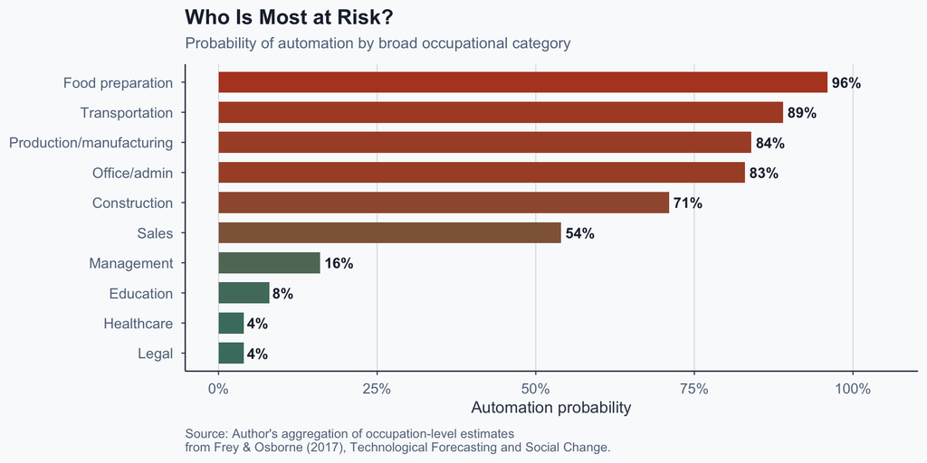

Figure 6: Estimated automation probability by occupation

## Lessons for Managing Technological Change

- Productivity gains do not automatically benefit everyone
- Institutional response time matters enormously
- Education and retraining are necessary but insufficient alone
- Collective voice (unions, democratic participation) accelerates adaptation
- Path dependence means early policy choices have long-run consequences

## Discussion Exercise 3

### Designing Institutions for AI

**Prompt:** You are advising a government on AI policy. Drawing on the Industrial Revolution, propose one institutional reform that could help manage the transition. Consider: Who are the likely losers? How fast must the response be? What failed or succeeded in the 1800s?

**Format:** Small groups (3–4), prepare a 1-minute pitch

**Time:** 5 minutes

## Key Takeaways

- The IR was a GPT-driven shock that reshaped economy and society
- Technology outpaced institutions for decades, causing inequality
- Workers bore the costs; capital owners captured the gains
- Institutional adaptation (regulation, education, unions) eventually followed
- Today’s AI revolution faces the same structural dynamics
- The speed and design of institutional response will determine outcomes

# References

## References

- Acemoglu, D., & Robinson, J. A. (2012). *Why nations fail*. Crown Publishers.
- Allen, R. C. (2009). Engels’ pause. *Explorations in Economic History*, 46(4), 418–435.
- Bolt, J., & van Zanden, J. L. (2020). Maddison style estimates. *Maddison Project Database*, v. 2020.
- Bresnahan, T. F., & Trajtenberg, M. (1995). General purpose technologies. *Journal of Econometrics*, 65(1), 83–108.
- Frey, C. B., & Osborne, M. A. (2017). The future of employment. *Technological Forecasting and Social Change*, 114, 254–280.
- Hobsbawm, E. J. (1962). *The age of revolution: 1789–1848*. Weidenfeld & Nicolson.
- Lipsey, R. G., Carlaw, K. I., & Bekar, C. T. (2005). *Economic transformations*. Oxford UP.
- Marx, K., & Engels, F. (1848). *The Communist Manifesto*.

## References

- Milgrom, P., & Roberts, J. (1990). The economics of modern manufacturing. *American Economic Review*, 80(3), 511–528.
- Mitchell, B. R. (1988). *British historical statistics*. Cambridge UP.
- Mokyr, J. (2002). *The gifts of Athena*. Princeton UP.
- Mokyr, J., Vickers, C., & Ziebarth, N. L. (2015). The history of technological anxiety. *Journal of Economic Perspectives*, 29(3), 31–50.
- Thompson, E. P. (1967). Time, work-discipline, and industrial capitalism. *Past & Present*, 38, 56–97.
- Wrigley, E. A. (2010). *Energy and the English Industrial Revolution*. Cambridge UP.